# Exponential Distribution Analysis

Tomas Gogorza

Monday, September 7, 2015

# Overview

This report is an investigation of the exponential distribution, with focus on taking several sample sets and comparing theoretical and sample means and variances, as well as showing distributions.

## 1 Simulations

Set up simulation variables

```r
lambda <- 0.2
#No. of simulations
nsim <- 1000
#No. of samples per simulation
n <- 40
```

Run 1000 simulations, take 40 samples from an exponential distribution for each one. The samples are arranged into a 1000x40 matrix, where each row representas a simulation with 40 samples.

```r
simulations <- matrix(rexp(nsim * n,lambda), nsim)
```

Calculate the mean and variance of each simulation. Store them on a list of 1000 items, where each element represent the mean (or variance) of one simulation.

```r
mns <- apply(simulations, 1, mean)
vars <- apply(simulations, 1, var)
```

## 2 Sample Mean vs Theoretical Mean

The theoretical mean for an exponential distribution is $1/\lambda$:

```r
mean <- 1/lambda
mean
```

```
## [1] 5
```

To measure the sample mean, we’ll get the list of means previously calculated and extract the mean of that list:

```r
samplemean <- mean(mns)
samplemean
```

```
## [1] 4.97694
```

We can see that the sample mean taken from the means of 1000 simulations is very similar to the theoretical mean for the exponential distribution Theoretical mean: **5**  
Sample mean: **4.9769398**

Draw comparative plots:

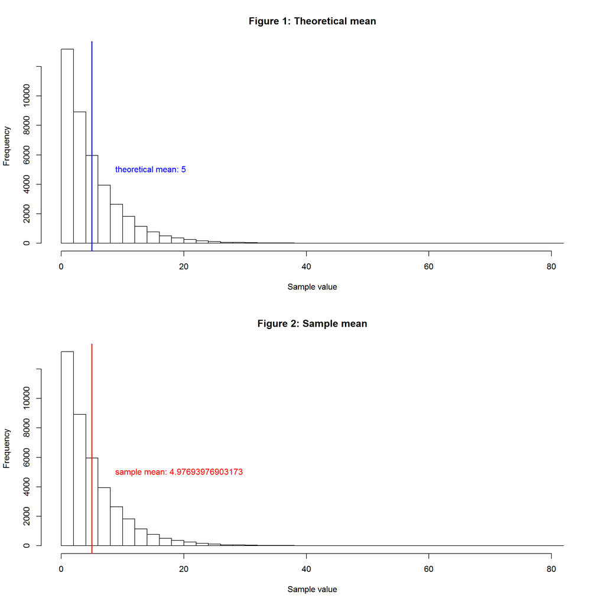

```r
par(mfrow=c(2,1))
hist(simulations,breaks = 50, xlab="Sample value", main="Figure 1: Theoretical mean")
abline(v = mean, col = "blue", lwd = 2)
text(mean+3, 5000 , paste("theoretical mean:", mean), pos = 4, col="blue")
hist(simulations,breaks = 50, xlab="Sample value", main="Figure 2: Sample mean")
abline(v = samplemean, col = "red", lwd = 2)
text(samplemean+3, 5000 , paste("sample mean:", samplemean), pos = 4, col="red")
```

**Figure 1.** Histogram of random samples and theoretical mean taken from an exponential distribution  
**Figure 2.** Histogram of random samples and sample mean taken from an exponential distribution

## 3 Sample Variance vs Theoretical Variance

Since $sd=\sqrt{var(X)}$, then $var(X)=sd^{2}$, therefore, given that for an exponential distribution $sd=1/\lambda$, the theoretical variance for an exponential distribution should be $1/\lambda^{2}$:

```r
sd <- 1/lambda
var <- sd^2
var
```

```
## [1] 25
```

To measure the sample variance, we’ll get the list of variances previously calculated and extract the mean of that list:

```r
#Take an average of the sample vars
samplevar <- mean(vars)
samplevar
```

```
## [1] 24.7899
```

We can effectively see that the sample variance taken from the variances of 1000 simulations is very similar to the theoretical variance for the exponential distribution Theoretical variance: **25**  
Sample variance: **24.7899019**

Draw comparative plots:

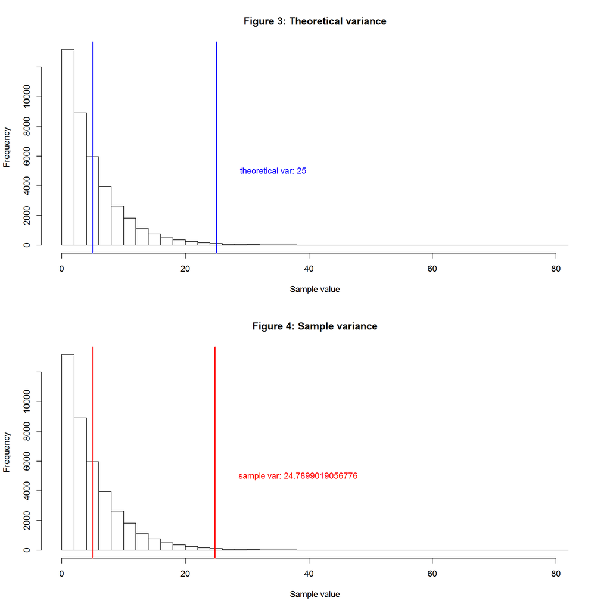

```r
par(mfrow=c(2,1))
hist(simulations,breaks = 50, xlab="Sample value", main="Figure 3: Theoretical variance")
abline(v = mean, col = "blue", lwd = 1)
abline(v = var, col = "blue", lwd = 2)
text(var+3, 5000 , paste("theoretical var:", var), pos = 4, col="blue")
hist(simulations,breaks = 50, xlab="Sample value", main="Figure 4: Sample variance")
abline(v = samplemean, col = "red", lwd = 1)
abline(v = samplevar, col = "red", lwd = 2)
text(samplevar+3, 5000 , paste("sample var:", samplevar), pos = 4, col="red")
```

**Figure 3.** Histogram of random samples, theoretical mean and theoretical variance taken from an exponential distribution  
**Figure 4.** Histogram of random samples, sample mean and sample variance taken from an exponential distribution

## 1.4 Distribution

Now we’ll show that the distribution is approximately normal. If we take the 1000 simulations with 40 ramdom samples each and consider it as just 1 simulation with 40000 random draws from en exponential distribution, we can see the distribution is indeed exponential:

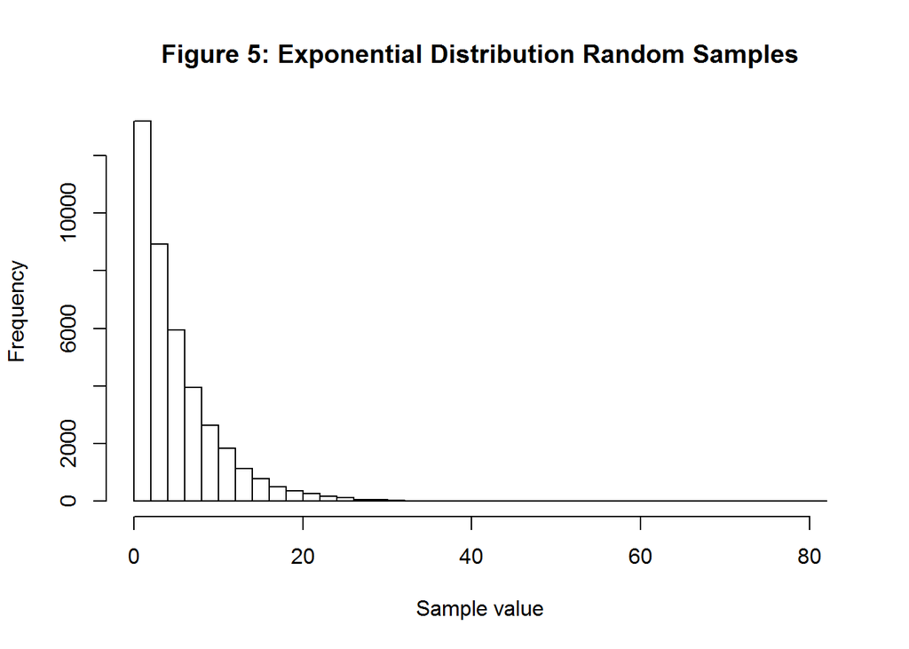

```r
hist(simulations,breaks=50, xlab="Sample value", main="Figure 5: Exponential Distribution Random Samples")
```

**Figure 5.** 40000 random samples drawn from an exponential distribution

Let’s take the means of the 1000 simulations we ran and plot a histogram:

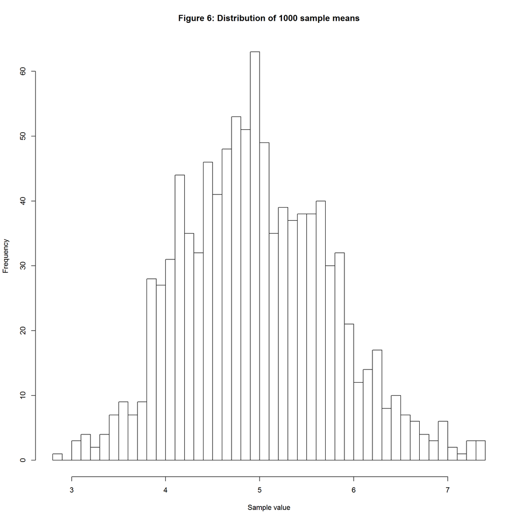

```r
hist(mns,breaks=50, xlab="Sample value", main="Figure 6: Distribution of 1000 sample means")
```

**Figure 6.** Distribution of the means of 1000 simulations

Per the **Central Limi Theorem**, we can effectively see that the distribution of the means of 1000 simulations (with 40 random samples each) is **approximately normal**.